# Data visualization for social networks

Xiang Wu

2019-10-20

### 图论概念

图的分类，按是否出现多重边（两个节点间存在多于一条边）或自环（存在一条边的两个顶点为同一顶点），可分为：

- 简单图：不出现多重边或自环，其边称为正常边。
- 多重图：出现多重边或自环。

图的连通性和距离概念包括：

- 邻接性(节点-节点)：两个节点通过一条边连接，那么这两个点是邻接的。这些节点可以称为邻居。
- 关联性(节点-边)：当节点是边的一个端点时，那么这个节点和这个边是关联的。
- 节点的度(节点)：与节点关联的边的数量。
- 通路(walk，节点-节点)：可以从一个节点通过其他节点和边到达另一个节点。
- 迹(trial，节点-节点)：不存在重复边的通路。
- 路径(path，节点-节点)：不存在重复节点的通路。
- 环(cycle，节点-节点)：起点和终点相同但其他所有节点都不同的长度至少为3的通路。
- 回路(circuit，节点-节点)：起点和终点相同的迹。
- 可达(reachable，节点-节点)：存在两个节点的通路，那么两个节点可达。
- 连通(connected，图)：所有节点彼此间均可达，那么图是连通的。
- 组件(component，子图)：最大化的连通子图，即任意增加V中的一个剩余节点都会破坏图的连通性。
- 距离(distance，节点-节点)：节点间的距离是节点间的最短路径的长度。
- 直径(diameter，图)：图中最长的距离

图的聚集性以集聚系数来衡量a-b,b-c条件下，a-c的可能性。具体包括：

- 整体集聚系数
- 局部集聚系数
- 平均集聚系数

其他概念还包括：

- 导出子图：给定全图G中的部分节点，包含这些节点以及节点之间的边的图。
- 团：两两之间有边的顶点集合。
- 互惠性：有向网络的边多大程度上是互惠的。

### 图的创建与属性

无向图和有向图的创建如下：

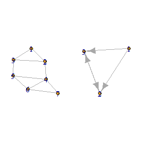

```r
# 无向图
g <- igraph::graph_from_literal(1-2, 1-3, 2-3, 2-4, 3-5, 4-5, 4-6,
                    4-7, 5-6, 6-7)
# 有向图
dg <- igraph::graph_from_literal(1-+2, 1-+3, 2++3)
par(mfrow=c(1, 2))
par(mar=c(1,1,1,1))
plot(g)
plot(dg)
```

特殊类型图的创建如下：

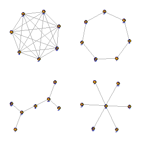

```r
# 其他特征图
g.full <- igraph::make_full_graph(7)
g.ring <- igraph::make_ring(7)
g.tree <- igraph::make_tree(7, children=2, mode="undirected")
g.star <- igraph::make_star(7, mode="undirected")
par(mfrow=c(2, 2))
par(mar=c(1,1,1,1))
plot(g.full)
plot(g.ring)
plot(g.tree)
plot(g.star)
```

```r
#par(mar=c(5.1 ,4.1, 4.1, 2.1))
```

图可以自定义属性:

```r
# 设置图属性
g$name <- "Toy Graph"

# 查看属性
igraph::graph_attr_names(g)
```

```
## [1] "name"
```

图的常用方法如下：

```r
# 输出vertice和edge
V(g)
```

```
## + 7/7 vertices, named, from 5b66067:
## [1] 1 2 3 4 5 6 7
```

```r
E(g)
```

```
## + 10/10 edges from 5b66067 (vertex names):
##  [1] 1--2 1--3 2--3 2--4 3--5 4--5 4--6 4--7 5--6 6--7
```

```r
# 输出vertice和edge的count
vcount(g)
```

```
## [1] 7
```

```r
ecount(g)
```

```
## [1] 10
```

```r
# 得到构成边的节点对
get.edgelist(g)
```

```
##       [,1] [,2]
##  [1,] "1"  "2"
##  [2,] "1"  "3"
##  [3,] "2"  "3"
##  [4,] "2"  "4"
##  [5,] "3"  "5"
##  [6,] "4"  "5"
##  [7,] "4"  "6"
##  [8,] "4"  "7"
##  [9,] "5"  "6"
## [10,] "6"  "7"
```

```r
# 得到边的连接矩阵
get.adjacency(g)
```

```
## 7 x 7 sparse Matrix of class "dgCMatrix"
##   1 2 3 4 5 6 7
## 1 . 1 1 . . . .
## 2 1 . 1 1 . . .
## 3 1 1 . . 1 . .
## 4 . 1 . . 1 1 1
## 5 . . 1 1 . 1 .
## 6 . . . 1 1 . 1
## 7 . . . 1 . 1 .
```

```r
# 是否是权重图
is.weighted(g)
```

```
## [1] FALSE
```

```r
# 是简单图还是多重图
is.simple(g)
```

```
## [1] TRUE
```

```r
# 是否连通
is.connected(g)
```

```
## [1] TRUE
```

```r
# 组件
clusters(g)
```

```
## $membership
## 1 2 3 4 5 6 7
## 1 1 1 1 1 1 1
##
## $csize
## [1] 7
##
## $no
## [1] 1
```

```r
decompose.graph(g)
```

```
## [[1]]
## IGRAPH 5e1f747 UN-- 7 10 -- Toy Graph
## + attr: name (g/c), name (v/c)
## + edges from 5e1f747 (vertex names):
##  [1] 1--2 1--3 2--3 2--4 3--5 4--5 4--6 4--7 5--6 6--7
```

```r
# 直径
diameter(g)
```

```
## [1] 3
```

```r
# 导出子图
h <- induced.subgraph(g, 1:5)

# 节点或边的纳入与排除
h <- h + vertices(c(6,7))
g <- h + edges(c(4,6),c(4,7),c(5,6),c(6,7))

# 集合论概念：并交差补
h1 <- h
h2 <- igraph::graph_from_literal(4-6, 4-7, 5-6, 6-7)
g1 <- graph.union(h1,h2)

# 团的普查
data(karate)
table(sapply(cliques(karate), length))
```

```
##
##  1  2  3  4  5
## 34 78 45 11  2
```

```r
# 极大团，不存在团的冗余
table(sapply(maximal.cliques(karate), length))
```

```
##
##  2  3  4  5
## 11 21  2  2
```

```r
# 最大团的尺寸，团数
clique.number(karate)
```

```
## [1] 5
```

```r
# k核图，所有节点至少为k的最大子图
cores <- graph.coreness(karate)

# 有向图二元组普查
aidsblog <- simplify(aidsblog)
dyad.census(aidsblog)
```

```
## $mut
## [1] 3
##
## $asym
## [1] 177
##
## $null
## [1] 10405
```

```r
# 密度
graph.density(karate)
```

```
## [1] 0.1390374
```

```r
# 全局聚类系数(三元组闭合的比例)
transitivity(karate)
```

```
## [1] 0.2556818
```

```r
# 局部聚类系数
transitivity(karate, "local", vids=c(1,34))
```

```
## [1] 0.1500000 0.1102941
```

```r
# 互惠性
reciprocity(aidsblog, mode="default")
```

```
## [1] 0.03278689
```

节点可以自定义属性，更多可以参看布局的修饰：

```r
# 设置节点属性
V(dg)$name <- c("Sam", "Mary", "Tom")
V(dg)$gender <- c("M","F","M")
V(dg)$color <- "red"

# 查看属性
list.vertex.attributes(dg)
```

```
## [1] "name"   "gender" "color"
```

节点的常用方法如下：

```r
# 节点的度
degree(g)
```

```
## 1 2 3 4 5 6 7
## 2 3 3 4 3 3 2
```

```r
# 节点的强度
graph.strength(g,2)  #节点相连边的权重和
```

```
## 2
## 3
```

```r
# 邻接性，邻居
neighbors(g,1)
```

```
## + 2/7 vertices, named, from 5e1f747:
## [1] 2 3
```

```r
# 节点邻居的平均度
graph.knn(g,c(1,2))$knn
```

```
## 1 2
## 3 3
```

边的属性设置如下，更多可以参看布局的修饰：

```r
# 设置权重属性
wg <- g
E(wg)$weight <- runif(ecount(wg))

# 查看属性
list.edge.attributes(wg)
```

```
## [1] "weight"
```

边的方法，尤其是涉及到相关聚集参数的方法，可以先将原来的图的点线进行转换，然后使用对应节点的方法即可。

### 图的可视化

图的布局有下面几种：

- 环形布局
- 弹簧模型
- 树结构（环形、辐射、分层）
- 增强的弹簧模型（适用大数据）

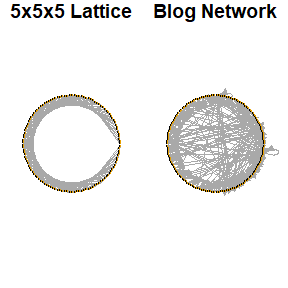

```r
par(mar=c(1,1,1,1))
# 载入数据
g.l <- igraph::make_lattice(c(5, 5, 5))
data(aidsblog)
aidsblog = upgrade_graph(aidsblog)

# 环形布局
igraph.options(vertex.size=3, vertex.label=NA,
   edge.arrow.size=0.5)
par(mfrow=c(1, 2))
plot(g.l, layout=layout.circle)
title("5x5x5 Lattice")
plot(aidsblog, layout=layout.circle)
title("Blog Network")
```

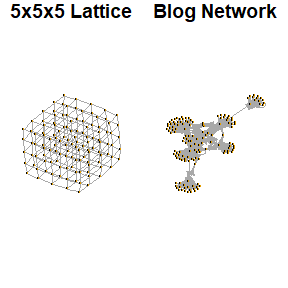

```r
# 弹簧布局
plot(g.l,layout=layout.fruchterman.reingold)
title("5x5x5 Lattice")
plot(aidsblog,layout=layout.fruchterman.reingold)
title("Blog Network")
```

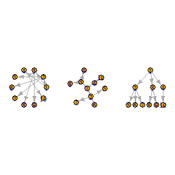

```r
# 树布局
g.tree <- igraph::graph_from_literal(1-+2,1-+3,1-+4,2-+5,2-+6,2-+7,
                         3-+8,3-+9,4-+10)
par(mfrow=c(1, 3))
igraph.options(vertex.size=30, edge.arrow.size=0.5,
   vertex.label=NULL)
plot(g.tree, layout=layout.circle)
plot(g.tree, layout=layout.reingold.tilford(g.tree,
   circular=T))
plot(g.tree, layout=layout.reingold.tilford)
```

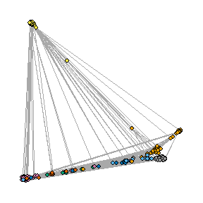

```r
# 增强的弹簧模型
par(mfrow=c(1, 1))
fblog = upgrade_graph(fblog)
party.names <- sort(unique(V(fblog)$PolParty))
party.nums.f <- as.factor(V(fblog)$PolParty)
party.nums <- as.numeric(party.nums.f)
l <- layout.drl(fblog)
plot(fblog, layout=l, vertex.size=5, vertex.label=NA,
   vertex.color=party.nums)
```

图的可视化中，节点的相对位置以及边的布置非常重要。如果存在其他的网络信息，可以通过调整节点和边的大小、形状、颜色加以整合实现布局的修饰。

具体地，有两种办法：

- 先画图再修饰
- 设置修饰参数后在画图

先画图再修饰如下：

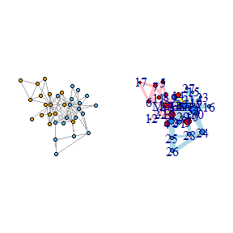

```r
par(mar=c(1,1,1,1))
igraph.options(vertex.size=10, vertex.label=NA,
   edge.arrow.size=0.5)
library(igraphdata)
data(karate)
karate = upgrade_graph(karate)
# 设置seed
set.seed(42)
l <- layout.kamada.kawai(karate)
# 先画未修饰的
par(mfrow=c(1,2))
plot(karate, layout=l, vertex.label=NA)
# 设置节点的名称
V(karate)$label <- sub("Actor ", "", V(karate)$name)
# 设置节点的形状
V(karate)$shape <- "circle"
V(karate)[c("Mr Hi", "John A")]$shape <- "rectangle"
# 设置节点的颜色
V(karate)[Faction == 1]$color <- "red"
V(karate)[Faction == 2]$color <- "dodgerblue"
# 设置节点的大小
V(karate)$size <- 4*sqrt(graph.strength(karate))
V(karate)$size2 <- V(karate)$size * .5
# 设置边的宽度
E(karate)$width <- E(karate)$weight
# 设置边的颜色
F1 <- V(karate)[Faction==1]
F2 <- V(karate)[Faction==2]
E(karate)[ F1 %--% F1 ]$color <- "pink"
E(karate)[ F2 %--% F2 ]$color <- "lightblue"
E(karate)[ F1 %--% F2 ]$color <- "yellow"
# 较小节点的标签位置偏移
V(karate)$label.dist <-
    ifelse(V(karate)$size >= 10, 0, 0.75)
# 再画修饰后的图形
plot(karate, layout=l)
```

设置修饰参数后在画图如下：

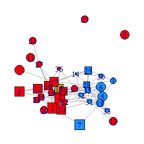

```r
par(mar=c(1,1,1,1))
par(mfrow=c(1,1))
data(lazega)
lazega = upgrade_graph(lazega)
# 节点颜色
colbar <- c("red", "dodgerblue", "goldenrod")
v.colors <- colbar[V(lazega)$Office]
# 节点形状
v.shapes <- c("circle", "square")[V(lazega)$Practice]
# 节点大小
v.size <- 3.5*sqrt(V(lazega)$Years)
# 节点标签
v.label <- V(lazega)$Seniority
set.seed(42)
l <- layout.fruchterman.reingold(lazega)
plot(lazega, layout=l, vertex.color=v.colors,
   vertex.shape=v.shapes, vertex.size=v.size,
   vertex.label=v.label)
```

### 图模型

随机图的“随机”二字体现在边的分布上。一个随机图实际上是将给定的顶点之间随机地连上边。假设将一些纽扣散落在地上，并且不断随机地将两个纽扣之间系上一条线，这样就得到一个随机图的例子。边的产生可以依赖于不同的随机方式，这样就产生了不同的随机图模型。例如，ER模型是指在给定n个顶点后，规定每两个顶点之间都有p的概率连起来且这些判定之间两两无关。

性质为：

- 节点对之间最短路径上的节点较少。
- 聚集性较低
- 随着边概率的不同，随机图可能会呈现不同的属性。对于最典型的ER模型，当p的值越过某些门槛时，ER随机图的性质会发生突然的改变。 例如，当概率p大于某个临界值pc后，生成的随机图几乎必然是连通的。

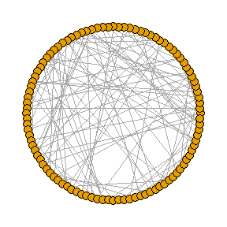

```r
par(mar=c(1,1,1,1))
# 生成
g.er <- erdos.renyi.game(100, 0.02)
plot(g.er, layout=layout.circle, vertex.label=NA)
```

```r
# 节点对之间最短路径上的节点较少
average.path.length(g.er)
```

```
## [1] 5.385863
```

```r
diameter(g.er)
```

```
## [1] 14
```

```r
# 聚集性较低
transitivity(g.er)
```

```
## [1] 0.04054054
```

广义随机图模型是在随机图的基础上，给定了固定的特征，然后随机生成图。性质为：

- 未选定的特征在保证选定特征不变的基础上可以自有变化。
- 原则上可以对图的定义进一步约束，从而保留度序列之外的其他特征，例如MCMC方法。

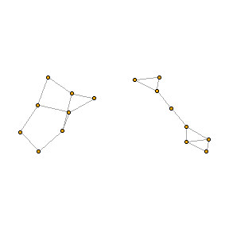

```r
par(mar=c(1,1,1,1))
# 生成
par(mfrow=c(1,2))
degs <- c(2,2,2,2,3,3,3,3)
g1 <- degree.sequence.game(degs, method="vl")
g2 <- degree.sequence.game(degs, method="vl")
plot(g1, vertex.label=NA)
plot(g2, vertex.label=NA)
```

```r
# 两个图都是满足特定要求生成的，不同构
graph.isomorphic(g1, g2)
```

```
## [1] FALSE
```

小世界网络就是一个由大量顶点构成的图，其中任意两点之间的平均路径长度比顶点数量小得多。直观地讲，网络有很高的集聚性，但多数节点之间的距离非常短。性质为：

- 高集聚系数
- 小的最短路径长度
- 常常出现枢纽

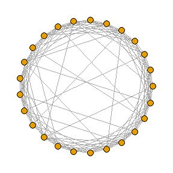

```r
par(mar=c(1,1,1,1))
par(mfrow=c(1,1))
# 1维 每个维度上25节点，5个邻居，重连概率0.05
g.ws <- sample_smallworld(1, 25, 5, 0.05)
plot(g.ws, layout=layout.circle, vertex.label=NA)
```

```r
# 高集聚系数
transitivity(g.ws)
```

```
## [1] 0.524144
```

```r
# 小的最短路径长度
average.path.length(g.ws)
```

```
## [1] 1.623333
```

```r
diameter(g.ws)
```

```
## [1] 3
```

优先连接模型体现了模型随时间增长演化的过程。核心机制是“富者越富”，也就是每次迭代新增加一个节点，节点和每个边有一定的概率相连，边的度越高那么相连的概率就越大。性质为：

- 当t(迭代次数)趋于无穷，图的度分布会趋向于一个幂指数为3的幂律分布。
- 节点对建最短路径上的节点较少
- 聚集性较低

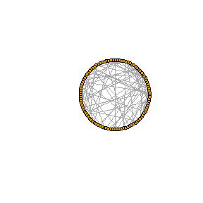

```r
# 生成

set.seed(42)
g.ba <- sample_pa(100, directed=FALSE)
# 可视化
plot(g.ba, layout=layout.circle, vertex.label=NA)
```

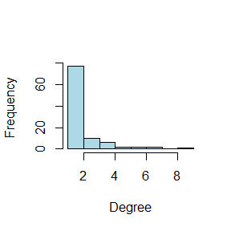

```r
# 度分布，体现很强的异质性，体现强者越强
hist(degree(g.ba), col="lightblue",
   xlab="Degree", ylab="Frequency", main="")
```

```r
# 节点对建最短路径上的节点较少
average.path.length(g.ba)
```

```
## [1] 5.815556
```

```r
diameter(g.ba)
```

```
## [1] 12
```

```r
# 聚集性较低
transitivity(g.ba)
```

```
## [1] 0
```